# Intro to R & Data Visualization

Alison Link  
30 November 2017

### Tutorials

https://linkalis.github.io/r-data-viz-basics-tutorials/

### Keep your projects organized together in separate folders–this helps R find them.

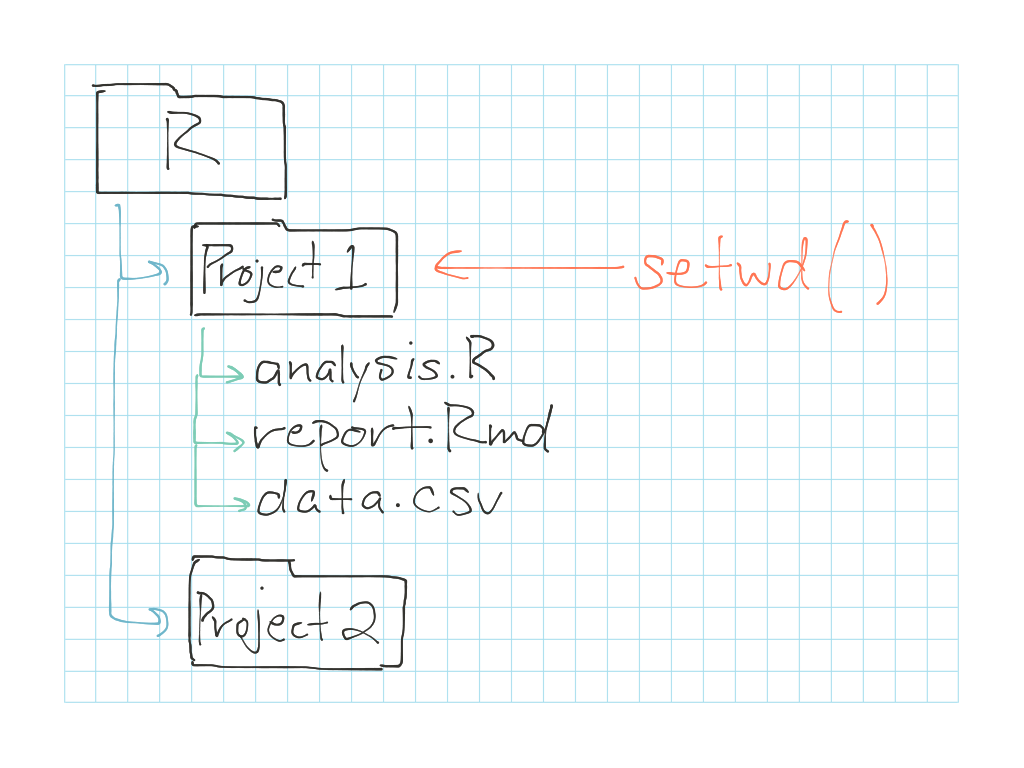

### The data stays behind the scenes, while you slice and dice it on the surface.

This head() function shows the first few rows of your data

```r
data <- read.csv("mpls_energy_benchmarking_2015.csv")

head(data)
```

```
         org_name                  prop_name public_private
1 Hennepin County               1800 Chicago         Public
2 Hennepin County            Central Library         Public
3 Hennepin County              Century Plaza         Public
4 Hennepin County      Family Justice Center         Public
5 Hennepin County Forensic Sciences Building         Public
6 Hennepin County          Government Center         Public
                   address zip_code energy_star_score      prop_type
1          1800 Chicago S.    55404                88         Office
2         300 Nicolet Mall    55401                 0          Other
3        330 south 12th st    55404                98         Office
4           110 S. 4th St.    55415                97     Courthouse
5 530 Chicago Avenue South    55415                 3 Medical Office
6             300 S. Sixth    55487                83     Courthouse
  floor_area floor_area_parking year_built total_GHG_emissions site_EUI
```

[output cut: 20 more lines]

The names() function shows you all of the variable names (column titles) that are present in your data

```r
names(data)
```

```
 [1] "org_name"                      "prop_name"
 [3] "public_private"                "address"
 [5] "zip_code"                      "energy_star_score"
 [7] "prop_type"                     "floor_area"
 [9] "floor_area_parking"            "year_built"
[11] "total_GHG_emissions"           "site_EUI"
[13] "weather_normalized_site_EUI"   "source_EUI"
[15] "weather_normalized_source_EUI" "water_use"
```

The str() function shows you additional information about a specific variable in your data

```r
str(data$year_built)
```

```
 int [1:415] 1996 2004 1934 1956 1974 1974 1989 1976 1983 1995 ...
```

### There are always multiple ways to do things–there’s never a single right answer!

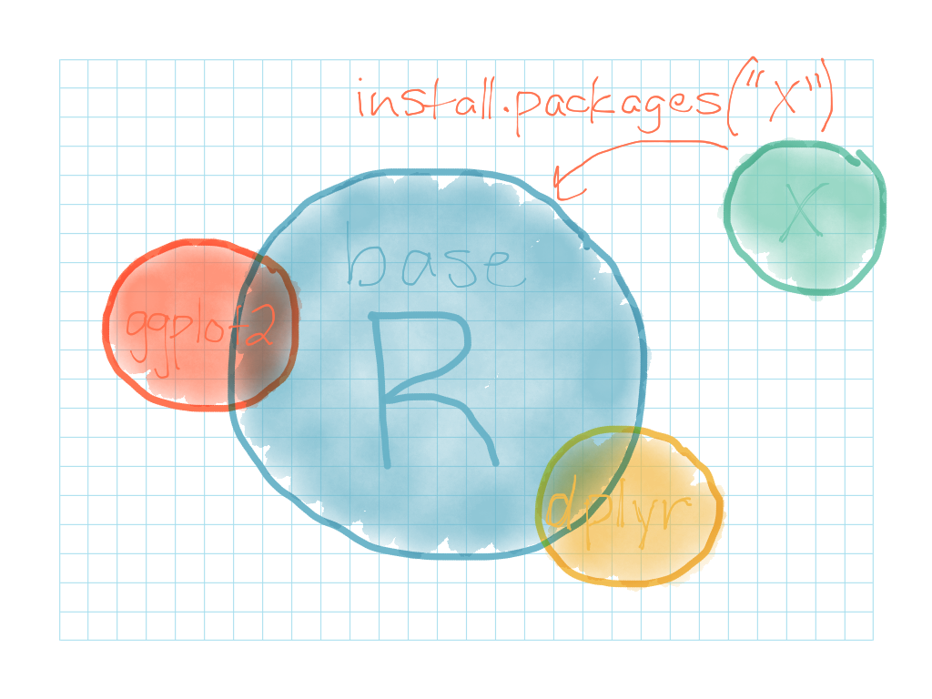

### Know the ways to ask for help

- Ask for help() in RStudio
- Learn how to Google for R help
  - Stack Overflow: (http://stackoverflow.com/questions/tagged/r)
  - R bloggers: (http://www.r-bloggers.com/)
  - Quick-R: (http://www.statmethods.net/)

### Expect error messages. They are your friends. Use the information they give you!

Activity: Google your errors

Here’s an R expression that yields an error message. Copy and paste each line of this code into the console in RStudio, then hit “Enter” to run the code. See if you can yield an error message:

```r
x <- c("A", "B", "C", "D", "E")
mean(x)
```

Why do you think this is throwing an error?

### A "first date" with your data in R/RStudio

1) Download the data from: https://linkalis.github.io/r-data-viz-basics-tutorials/

2) Read in the data:

```r
data <- read.csv("mpls_energy_benchmarking_2015.csv", header=TRUE, na.strings=c("N/A", "Not Available", "NA", "0"))
```

Activity: Get to know your data

Pick a variable in the dataset and run the `summary()` command on it. What do you see?

Pick a variable in the dataset and run the `str()` command on it. What data type does it appear to be? Note that R sometimes guesses wrong about the type of data it thinks is contained in a variable/column. For the variable you selected, does it seem like R guessed correctly, or did it pick a data type that seems wrong based on your understanding of what the variable is supposed to be measuring?

### Have your cake, or eat it?

Calling a function command …

```r
table(data$prop_type)
```

…vs. assigning the result of a function to a variable.

```r
building_types <- table(data$prop_type)
```

Making a new column:

```r
data$years_ago <- 2016 - data$year_built
```

### Data frames

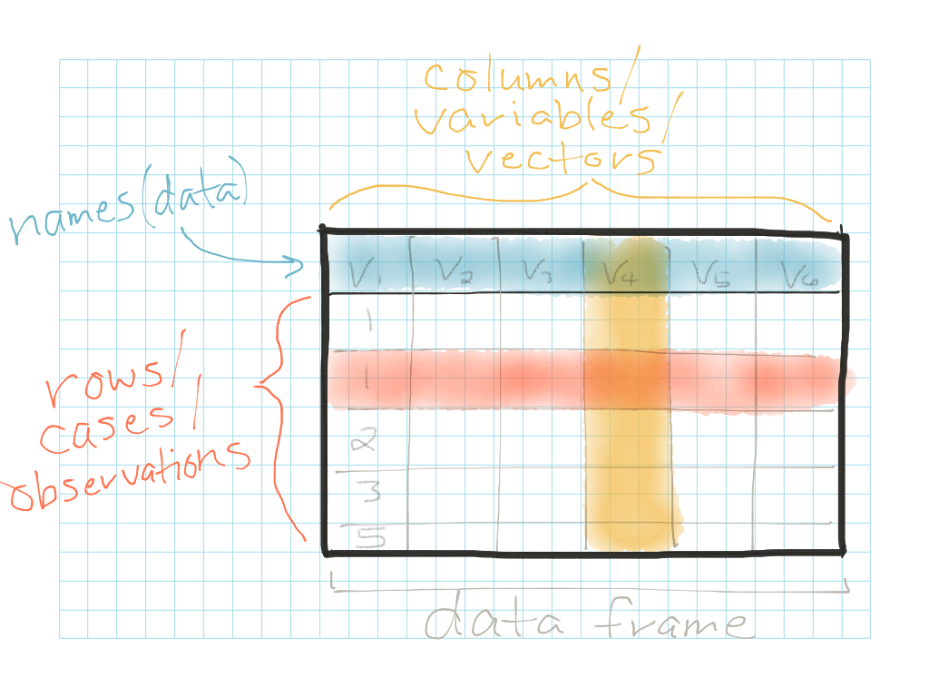

### Vectors

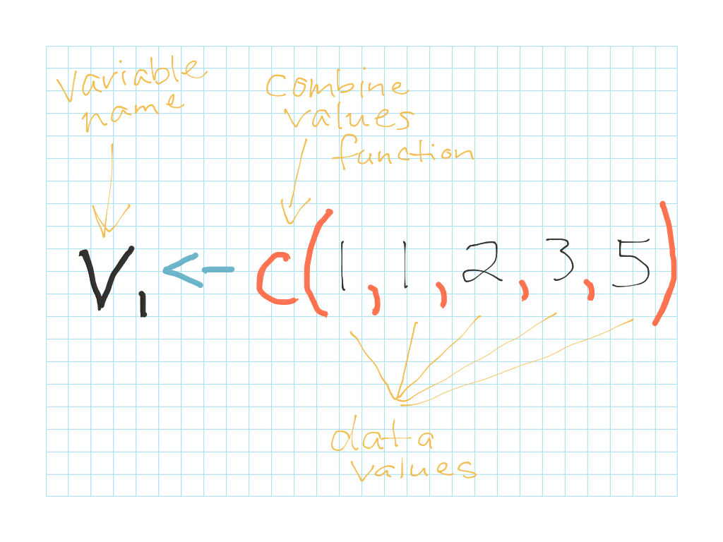

### Data types: The “flavors” of data

| R data type | What type of data does it contain? | Example |
| --- | --- | --- |
| **Character (“chr”)** | letters and other text characters (aka “strings” in programming speak) | players' first and last names |
| **Numeric (“num”)** | numbers, including negative numbers and numbers with decimal points | weight, height |
| **Integer (“int”)** | similar to numeric, but for whole numbers, including negative whole numbers | age, social security number |
| **Logical (“logi”)** | information on true/false questions | “this person has participated before”, “this person is a vegetarian” |
| **Factor** | unordered *or* ordered categorical information | team they're on (unordered categorical variable); T-shirt size (S, M, L, XL) (ordered categorical variable) |

```r
# Character vector
player_name <- c("Abdi", "Brit", "Chloe", "Dani", "Ed")

# Numeric vector
player_weight <- c(150.5, 220.8, 135.2, 125.1, 180.2)

# Integer vector
player_age <- c(18, 20, 24, 19, 22)

# Logical vector
vegetarian <- c(TRUE, FALSE, FALSE, TRUE, FALSE)

# Factor vector
tshirt_size <- factor(c("L", "XL", "S", "S", "M"), levels=c("S", "M", "L", "XL"))

# Combine into a data frame
baseball_tournament_df <- data.frame(player_name, player_weight, player_age, vegetarian, tshirt_size)
```